# Systems Integration

Motivation

Prof. Dr. Christian Drumm

2026-10-02

# Motivation

## Exercise 1

### Scenario

A small to medium-sized company sells **bike parts online**, catering to both individual consumers and small, independent bike shops.

- Products are shipped from a **company-owned warehouse**
- In addition to the online store, the company operates a **flagship store** in the city center

### Your Task

Form small groups of **3–4 students** and discuss:

- **Identify Key Processes**
  - Essential business processes, manual and automated
- **Determine Supporting Systems**
  - Which information systems support these processes?
- **Analyze Integration Needs**
  - How should the systems interact?
  - Is integration with external partners’ systems necessary?

> Prepare **one slide** summarizing your key findings.

## Exercise 2

### Scenario

Two systems connected by an arrow:

- **System X** — could be a Customer Relationship Management (CRM) system
- **System Y** — might be an invoicing or billing system

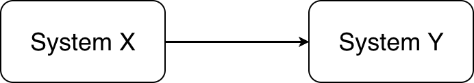

Abstract integration scenario

## Exercise 2

### You Task

Form small groups of **3–4 students** and discuss what the arrow might represent:

- What kind of **interaction** does the arrow symbolize? Data flow, process flow, something else?
- What **challenges** might arise?
  - Data consistency
  - Performance
  - Scalability
- What are the **implications** for reliability, security, efficiency?
- How could different **integration patterns** influence this interaction? For example, what would be the difference between synchronous and asynchronous communication.

> Prepare **one slide** summarizing your key findings.

## Prior Knowledge

1. Overview and processes in ERP systems (cf. [SAP in der Praxis](http://drumm.sh/sap) & [Business Information Systems](http://drumm.sh/bis))
2. At least one programming language ([Python MOOC](https://open.hpi.de/learn/python2025))
3. Basic knowledge of HTML and HTTP ([W3C HTML Tutorial](https://www.w3schools.com/html/), [W3C What is HTTP](https://www.w3schools.com/whatis/whatis_http.asp))
4. Data Modelling, Databases and SQL ([W3C SQL Tutorial](https://www.w3schools.com/sql/), [Datenmodellierung](https://link.springer.com/book/10.1007/978-3-658-19069-9))
5. Process Modelling ([BPMN](http://drumm.is))
6. Basic usage of a Unix shell like [Bash](https://en.wikipedia.org/wiki/Bash_%28Unix_shell%29) or [ZSH](https://en.wikipedia.org/wiki/Z_shell) ([W3C Bash Tutorial](https://www.w3schools.com/bash/))

## Wrap-Up

- Every business process relies on **multiple systems**
- Systems that don’t talk to each other create **silos**
- Integration is about making systems **work together**, reliably, securely, and efficiently